# Text Mining With R

```r
library(data.table)
library(magrittr)
library(tidytext)
library(textdata)
library(widyr)
library(magrittr)
library(janeaustenr)
library(gutenbergr)
library(igraph)
library(grid)
library(gtable)
library(ggplot2)
library(stringr)
library(RtextminerPkg)
library(RplotterPkg)
```

Author: Rick Dean

Article date: 2021-01-07

Abstract

The following notes/R scripts were inspired from Chapter 4 of [Text Mining With R](https://www.tidytextmining.com/index.html) by Julia Silge and David Robinson

Note: Functions from the `data.table` and `RtextminerPkg` packages are used in performing many of the following data set operations.

# Relationships between words

## Tokenizing by n-gram

Tokenize into consecutive sequences of words, called n-grams. By seeing how often word X is followed by word Y we can then build a model of the relationship between them.

### Using RtextminerPkg::tokenize_text to produce n-grams

1. Get the Austen books:

```r
austen_books_dt <- data.table::setDT(janeaustenr::austen_books())
head(austen_books_dt)
##                     text                book
## 1: SENSE AND SENSIBILITY Sense & Sensibility
## 2:                       Sense & Sensibility
## 3:        by Jane Austen Sense & Sensibility
## 4:                       Sense & Sensibility
## 5:                (1811) Sense & Sensibility
## 6:                       Sense & Sensibility
```

2.Call RtextminerPkg::tokenize_text:

```r
austen_bigrams_dt <- RtextminerPkg::tokenize_text(
  x = austen_books_dt,
  type = "ngram",
  output_col = "bigram",
  strip_punct = T,
  stopwords = tidytext::stop_words$word
)
head(austen_bigrams_dt$tokens_dt)
##                   book  token_1     token_2             ngram
## 1: Sense & Sensibility    sense sensibility sense sensibility
## 2: Sense & Sensibility     jane      austen       jane austen
## 3: Sense & Sensibility  chapter           1         chapter 1
## 4: Sense & Sensibility   family    dashwood   family dashwood
## 5: Sense & Sensibility dashwood     settled  dashwood settled
## 6: Sense & Sensibility  settled      sussex    settled sussex
```

Note: Each row shows both the bigram words separated and concatenated. `RtextminerPkg::tokenize_text()` in its output list also has a data.table (named *austen_bigrams_dt$tokens_count*) that has the bigram counts. Here is a look at that data.table with the counts in descending order:

```r
head(austen_bigrams_dt$tokens_count)
##    token_1   token_2   N
## 1:     sir    thomas 266
## 2:    miss  crawford 196
## 3:    miss woodhouse 143
## 4: captain wentworth 143
## 5:   frank churchill 114
## 6:    lady   russell 110
```

We can see that proper names are the most common pairs in Jane Austen books.

### Create a trigram of the books

```r
trigram_dt <- RtextminerPkg::tokenize_text(
  x = austen_books_dt,
  type = "ngram",
  n_gram = 3L,
  output_col = "trigram",
  strip_punct = T,
  stopwords = tidytext::stop_words$word
)
head(trigram_dt$tokens_count)
##      token_1   token_2   token_3  N
## 1:      dear      miss woodhouse 20
## 2:      miss        de    bourgh 17
## 3:      lady catherine        de 11
## 4:      poor      miss    taylor 11
## 5:       sir    walter    elliot 10
## 6: catherine        de    bourgh  9
```

## Analyzing bigrams

### The most common streets in each book

```r
bigrams_filtered_dt <- austen_bigrams_dt$tokens_dt[token_2 == "street", .(N = .N), by = .(book, token_1)][order(-N)]
head(bigrams_filtered_dt)
##                   book     token_1  N
## 1: Sense & Sensibility      harley 16
## 2: Sense & Sensibility    berkeley 15
## 3:    Northanger Abbey    pulteney 10
## 4:    Northanger Abbey      milsom 10
## 5:      Mansfield Park     wimpole  9
## 6:   Pride & Prejudice gracechurch  8
```

### Compute tf-idf for bigrams

1. Call `RtextminerPkg::get_tf_idf()`:

```r
level_1_dt <- RtextminerPkg::get_tf_idf(
  x = austen_books_dt,
  type = "ngram",
  feature_id = "book",
  feature_text = "text",
  n_gram = 2L,
  strip_punct = T,
  stopwords = tidytext::stop_words$word
)
head(level_1_dt)
##        feature_id             ngram token_n feature_n          tf      idf
## 1:     Persuasion captain wentworth     143     18394 0.007774274 1.791759
## 2: Mansfield Park        sir thomas     266     34826 0.007637972 1.791759
## 3:     Persuasion      lady russell     110     18394 0.005980211 1.791759
## 4:     Persuasion        sir walter     108     18394 0.005871480 1.791759
## 5: Mansfield Park     miss crawford     196     34826 0.005627979 1.791759
## 6:           Emma    miss woodhouse     143     33379 0.004284131 1.791759
##         tf_idf
## 1: 0.013929629
## 2: 0.013685408
## 3: 0.010715100
## 4: 0.010520280
## 5: 0.010083985
## 6: 0.007676132
```

2. For plotting select the top 15 “token” values in each book subgroup:

```r
level_2_dt <- level_1_dt[, setorder(.SD, -tf_idf)[1:15], by = feature_id]
head(level_2_dt)
##    feature_id             ngram token_n feature_n          tf      idf
## 1: Persuasion captain wentworth     143     18394 0.007774274 1.791759
## 2: Persuasion      lady russell     110     18394 0.005980211 1.791759
## 3: Persuasion        sir walter     108     18394 0.005871480 1.791759
## 4: Persuasion   captain benwick      48     18394 0.002609547 1.791759
## 5: Persuasion       miss elliot      39     18394 0.002120257 1.791759
## 6: Persuasion  captain harville      33     18394 0.001794063 1.791759
##        tf_idf
## 1: 0.01392963
## 2: 0.01071510
## 3: 0.01052028
## 4: 0.00467568
## 5: 0.00379899
## 6: 0.00321453
```

3. Plot the if_idf values:

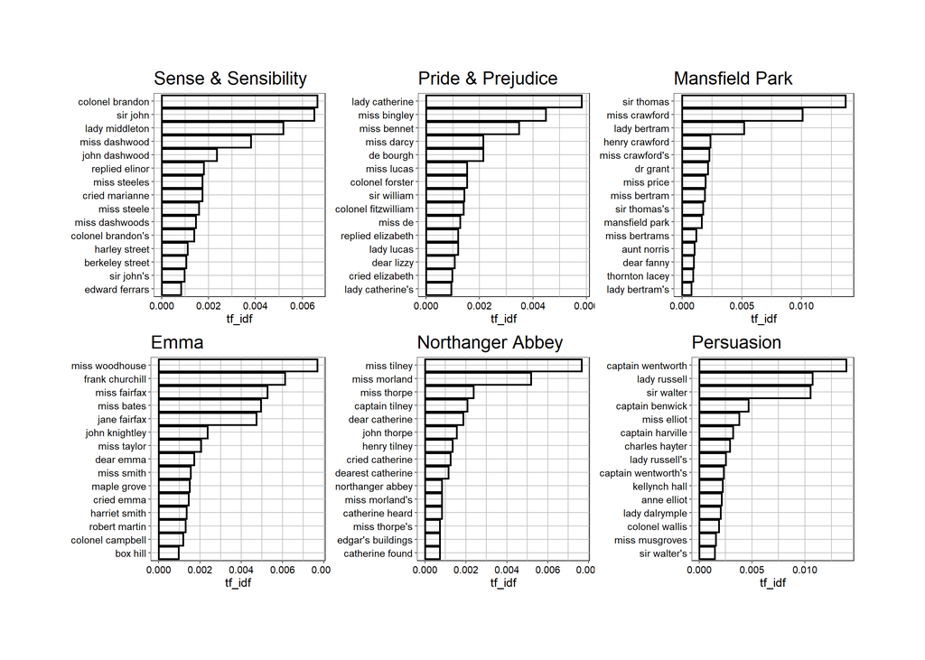

```r
tf_idf_plot <- RplotterPkg::multi_bar_plot(
    df = level_2_dt,
    factor_var = "feature_id",
    factor_x = "ngram",
    columns = 3,
    aes_y = "tf_idf",
    y_titles = rep("tf_idf",6),
    rot_y_tic_label = TRUE,
    do_coord_flip = TRUE,
    order_bars = "asc"
)
```

## Using bigrams to provide context in sentiment analysis

By using bigrams we can get a sense of the context of a single word.

### How often are words preceded by the word “not”

1. Get bigrams without stopwords:

```r
austen_bigrams_dt <- RtextminerPkg::tokenize_text(
  x = austen_books_dt,
  type = "ngram",
  output_col = "bigram",
)
```

2. Filter out “not” for the first token:

```r
level_1_dt <- austen_bigrams_dt$tokens_dt[token_1=="not", .(N = .N), by = .(token_1, token_2)][order(-N)]
head(level_1_dt)
##    token_1 token_2   N
## 1:     not      be 580
## 2:     not      to 335
## 3:     not    have 307
## 4:     not    know 237
## 5:     not       a 184
## 6:     not   think 162
```

### Get a FINN sentiment value for bigrams that start with “not”

1. Set up the FINN sentiment values:

```r
afinn_dt <- data.table::setDT(textdata::lexicon_afinn())
head(afinn_dt)
##          word value
## 1:    abandon    -2
## 2:  abandoned    -2
## 3:   abandons    -2
## 4:   abducted    -2
## 5:  abduction    -2
## 6: abductions    -2
```

2. Filter “not” words:

```r
level_1_dt <- austen_bigrams_dt$tokens_dt[token_1=="not", .(word = token_2)]
head(level_1_dt)
##      word
## 1: merely
## 2:     to
## 3:    the
## 4:     an
## 5: repent
## 6:    the
```

3. Join FINN scores with “not” words:

```r
data.table::setkey(level_1_dt, word)
data.table::setkey(afinn_dt, word)
level_2_dt <- afinn_dt[level_1_dt]
level_2_dt <- na.omit(level_2_dt, cols = "value")
head(level_2_dt)
##      word value
## 1:  abuse    -3
## 2: accept     1
## 3: accept     1
## 4: accept     1
## 5: accuse    -2
## 6: accuse    -2
```

4. Get an ordered count of the values:

```r
level_3_dt <- level_2_dt[, .(N = .N), by = .(word, value)][order(-N)]
head(level_3_dt)
##     word value  N
## 1:  like     2 95
## 2:  help     2 77
## 3:  want     1 41
## 4:  wish     1 39
## 5: allow     1 30
## 6:  care     2 21
```

5. Create variables for *contribution* = *value* * *N* and *fill* = *value* * *N* > 0:

```r
level_4_dt <- level_3_dt[, .(word, value, N, contribution = value * N, fill = value * N > 0)][order(-abs(contribution))][1:20]
head(level_4_dt)
##    word value  N contribution fill
## 1: like     2 95          190 TRUE
## 2: help     2 77          154 TRUE
## 3: love     3 15           45 TRUE
## 4: care     2 21           42 TRUE
## 5: want     1 41           41 TRUE
## 6: wish     1 39           39 TRUE
```

6. Create a bar plot of the *contribution* values:

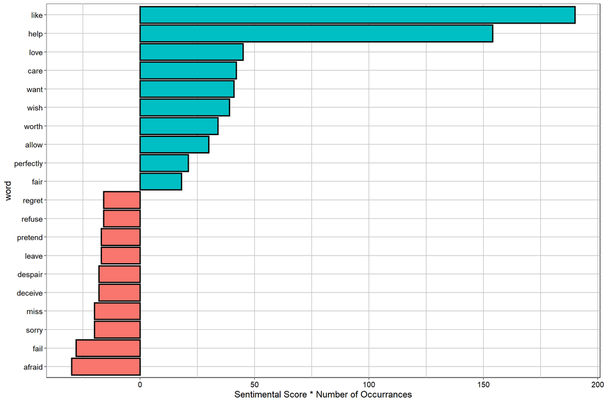

```r
RplotterPkg::create_bar_plot(
  df = level_4_dt,
  aes_x = "word",
  aes_y = "contribution",
  y_title = "Sentimental Score * Number of Occurrances",
  aes_fill = "fill",
  do_coord_flip = T,
  rot_y_tic_label = T,
  order_bars = "asc",
  show_legend = F
)
```

“not like” and “not help” have the largest causes of misidentification, making the book seem more positive than it is. Also “not afraid” and “not fail” suggest the book is more negative than it is.

### Four words that negate the subsequent term

1. Select the four words and filter the bigrams for those words:

```r
negation_words <- c("not", "no", "never", "without")

level_1_dt <- austen_bigrams_dt$tokens_dt[token_1 %in% negation_words, .(token_1, word = token_2)]
head(level_1_dt)
##    token_1   word
## 1:     not merely
## 2:      no  power
## 3:      no  means
## 4:     not     to
## 5:      no longer
## 6:     not    the
```

2. Join FINN scores with “negated” words:

```r
data.table::setkey(level_1_dt, word)
data.table::setkey(afinn_dt, word)
level_2_dt <- afinn_dt[level_1_dt]
level_2_dt <- na.omit(level_2_dt, cols = "value")
head(level_2_dt)
##         word value token_1
## 1:     abuse    -3     not
## 2:    accept     1     not
## 3:    accept     1     not
## 4:    accept     1     not
## 5: accepting     1 without
## 6:  accident    -2 without
```

3. Get a subgroup count:

```r
level_3_dt <- level_2_dt[, .(N = .N), by = .(token_1, word, value)]
head(level_3_dt)
##    token_1       word value N
## 1:     not      abuse    -3 1
## 2:     not     accept     1 3
## 3: without  accepting     1 1
## 4: without   accident    -2 2
## 5:      no accusation    -2 1
## 6:     not     accuse    -2 2
```

5. Define variables *contribution* = *value* * *N* and *fill* = *value* * *N* > 0:

```r
level_4_dt <- level_3_dt[, .(token_1, word, value, N, contribution = value * N, fill = value * N > 0)]
head(level_4_dt)
##    token_1       word value N contribution  fill
## 1:     not      abuse    -3 1           -3 FALSE
## 2:     not     accept     1 3            3  TRUE
## 3: without  accepting     1 1            1  TRUE
## 4: without   accident    -2 2           -4 FALSE
## 5:      no accusation    -2 1           -2 FALSE
## 6:     not     accuse    -2 2           -4 FALSE
```

6. Define an absolute value for *contribution*:

```r
level_4_dt[, contribution_abs := abs(contribution)]
head(level_4_dt)
##    token_1       word value N contribution  fill contribution_abs
## 1:     not      abuse    -3 1           -3 FALSE                3
## 2:     not     accept     1 3            3  TRUE                3
## 3: without  accepting     1 1            1  TRUE                1
## 4: without   accident    -2 2           -4 FALSE                4
## 5:      no accusation    -2 1           -2 FALSE                2
## 6:     not     accuse    -2 2           -4 FALSE                4
```

7. Group by *token_1* and order the subgroups by *contribution_abs*

```r
#negated_words_ordered_dt <- negated_words_contrib_dt[, .(word, value, N, contribution,fill), by = token_1][order(-contribution)][1:80]

level_5_dt <- level_4_dt[, setorder(.SD, -contribution_abs)[1:15], by = token_1]
head(level_5_dt)
##    token_1 word value  N contribution fill contribution_abs
## 1:     not like     2 95          190 TRUE              190
## 2:     not help     2 77          154 TRUE              154
## 3:     not love     3 15           45 TRUE               45
## 4:     not care     2 21           42 TRUE               42
## 5:     not want     1 41           41 TRUE               41
## 6:     not wish     1 39           39 TRUE               39
```

8. Plot the negated words:

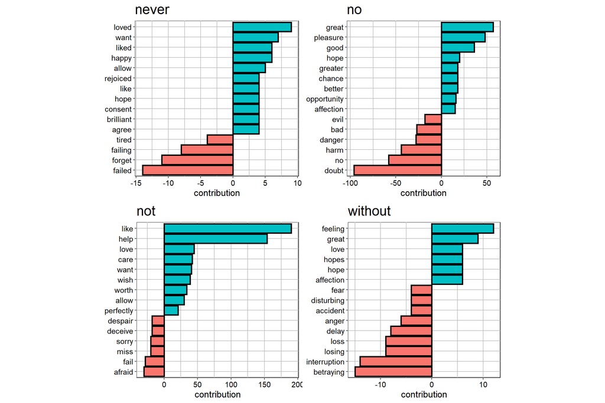

```r
RplotterPkg::multi_bar_plot(
  df = level_5_dt,
  factor_var = "token_1",
  factor_x = "word",
  aes_y = "contribution",
  aes_fill = "fill",
  y_titles = rep("Sentimental Score * Number of Occurrances",4),
  rot_y_tic_label = T,
  do_coord_flip = T,
  order_bars = "asc",
  show_legend = F
)
```

## Counting and correlating pairs of words

### Counting pairs of words

Divide “Pride and Prejudice” into 10-line sections and see what words tend to appear in the same section.

1. Get “Pride & Prejudice”:

```r
austen_text_dt <- data.table::setDT(austen_books(), keep.rownames = T)
austen_text_dt <- austen_text_dt[book == "Pride & Prejudice", .(rn = as.numeric(rn), text)]
head(austen_text_dt)
##       rn                text
## 1: 12625 PRIDE AND PREJUDICE
## 2: 12626
## 3: 12627      By Jane Austen
## 4: 12628
## 5: 12629
## 6: 12630
```

2. Create a *section* variable:

```r
austen_text_section_dt <- austen_text_dt[, section := (rn - 12624) %/% 10] %>%
  .[section > 0,]
head(austen_text_section_dt)
##       rn
## 1: 12634
## 2: 12635
## 3: 12636
## 4: 12637
## 5: 12638
## 6: 12639
##                                                                        text
## 1:  It is a truth universally acknowledged, that a single man in possession
## 2:                            of a good fortune, must be in want of a wife.
## 3:
## 4:   However little known the feelings or views of such a man may be on his
## 5: first entering a neighbourhood, this truth is so well fixed in the minds
## 6: of the surrounding families, that he is considered the rightful property
##    section
## 1:       1
## 2:       1
## 3:       1
## 4:       1
## 5:       1
## 6:       1
```

3. Tokenize text into words:

```r
austen_tokens_lst <- RtextminerPkg::tokenize_text(
  x = austen_text_section_dt,
  stopwords = tidytext::stop_words$word,
  strip_punct = T
)
austen_section_words_dt <- austen_tokens_lst$tokens_dt
head(austen_section_words_dt)
##       rn section         word
## 1: 12634       1        truth
## 2: 12634       1  universally
## 3: 12634       1 acknowledged
## 4: 12634       1       single
## 5: 12634       1   possession
## 6: 12635       1      fortune
```

4. Get the count of specific word pairs:

```r
austen_word_pairs_df <- austen_section_words_dt %>%
  widyr::pairwise_count(
    item = word,
    feature = section,
    sort = T
  )
austen_word_pairs_dt <- data.table::setDT(austen_word_pairs_df)
head(austen_word_pairs_dt)
##        item1     item2   n
## 1:     darcy elizabeth 144
## 2: elizabeth     darcy 144
## 3:      miss elizabeth 110
## 4: elizabeth      miss 110
## 5: elizabeth      jane 106
## 6:      jane elizabeth 106
```

5. Find the count of word pairs where the first word is “darcy”:

```r
darcy_wrds_dt <- austen_word_pairs_dt[item1 == "darcy"]
str(darcy_wrds_dt)
## Classes 'data.table' and 'data.frame':   2930 obs. of  3 variables:
##  $ item1: chr  "darcy" "darcy" "darcy" "darcy" ...
##  $ item2: chr  "elizabeth" "miss" "bingley" "jane" ...
##  $ n    : num  144 92 86 46 45 45 41 38 37 37 ...
##  - attr(*, ".internal.selfref")=<externalptr>
```

### Correlating pairs of words

> The `widyr::pairwise_cor()` function lets us find the phi coefficient between words based on how often they appear in the same section.

To compute pairwise word correlation, complete the following 3 steps:

1. Group *austen_section_wrds_dt* by *word* and filter out words with counts greater or equal to 20:

```r
freq_wrds_dt <- austen_section_words_dt[,.(.N), by = word] %>%
  .[N >= 20] %>%
  .[order(-N)]
```

2. Filter *austen_section_words_dt* for just those words in *freq_wrds_dt*:

```r
freq_wrds_section <- austen_section_words_dt[word %in% freq_wrds_dt$word]
```

3. Compute word correlations:

```r
cor_wrds_df <-  widyr::pairwise_cor(freq_wrds_section,word, section, sort = TRUE)
cor_wrds_dt <- data.table::setDT(cor_wrds_df)
head(cor_wrds_dt)
##       item1    item2 correlation
## 1:   bourgh       de   0.9508501
## 2:       de   bourgh   0.9508501
## 3:   pounds thousand   0.7005808
## 4: thousand   pounds   0.7005808
## 5:  william      sir   0.6644719
## 6:      sir  william   0.6644719
```

### Words correlated with a single word

Find words most correlated with “pounds”:

```r
cor_pounds_dt <- cor_wrds_dt[item1 == "pounds"]
head(cor_pounds_dt)
##     item1     item2 correlation
## 1: pounds  thousand   0.7005808
## 2: pounds       ten   0.2305758
## 3: pounds   fortune   0.1638626
## 4: pounds   settled   0.1494605
## 5: pounds wickham's   0.1415240
## 6: pounds  children   0.1290001
```

### Words correlated with a group of words

1. Select the group of words:

```r
group_word_cor <- cor_wrds_dt[item1 %in% c("elizabeth", "pounds", "married", "pride"),.SD[1:6], by = item1]
head(group_word_cor)
##     item1     item2 correlation
## 1: pounds  thousand   0.7005808
## 2: pounds       ten   0.2305758
## 3: pounds   fortune   0.1638626
## 4: pounds   settled   0.1494605
## 5: pounds wickham's   0.1415240
## 6: pounds  children   0.1290001
```

2. Plot the word correlations for each group word:

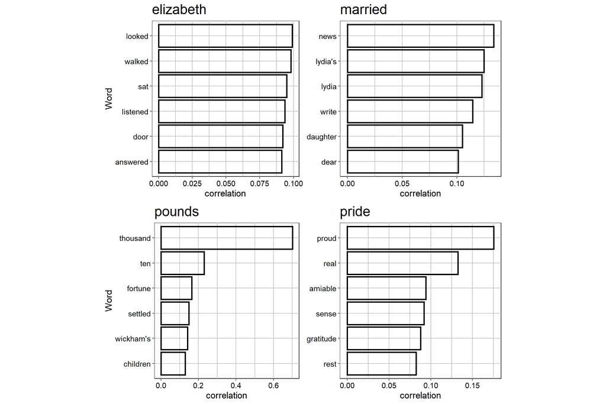

```r
RplotterPkg::multi_bar_plot(
  df = group_word_cor,
  factor_var = "item1",
  factor_x = "item2",
  aes_y = "correlation",
  x_title = "Word",
  rot_y_tic_label = T,
  do_coord_flip = T,
  order_bars = "asc"
)
```